# County Health Rankings

This is an analysis of the Robert Wood Johnson Foundation County Health Rankings.

Setting the working directory

```r
setwd("C:/Users/natek/Documents/County Health Rankings Analysis")
```

Loading libraries

```r
library(tidyverse)
```

I tried reading in the 2014, 2015, 2016, and 2017 data. Unfortunately, all of them are messy datasets and will need to be cleaned up individually before combining any of them. So I’ll start with 2017 and return to the others later.

There are two columns that caused difficulty for ’read_csv()`, so I read them in as characters and will fix them if they’re required for the analysis

```r
chr_df_17 = read_csv("data/2017CHR_CSV_Analytic_Data.csv",
                       col_types = cols(
                       measure_127_value = col_character(),
                       measure_131_value = col_character()
                       )
                      )
chr_df_17 = chr_df_17 %>% rename(FIPS = fipscode) #renaming a variable for use in the function below
```

Next I’ll take just our peer cities and add columns indicating baseline or current peer

```r
pull_all_peers <- function(data){
  data = data %>% filter(data$FIPS == "01073" |data$FIPS == "37119"
                       |data$FIPS == "39061" |data$FIPS == "39049"
                       |data$FIPS == "26081" |data$FIPS == "37081"
                       |data$FIPS == "45045" |data$FIPS == "18097"
                       |data$FIPS == "29095" |data$FIPS == "47093"
                       |data$FIPS == "21111" |data$FIPS == "47157"
                       |data$FIPS == "47037" |data$FIPS == "40109"
                       |data$FIPS == "31055" |data$FIPS == "29189"
                       |data$FIPS == "29510"
                       |data$FIPS == "40143" |data$FIPS == "39113"
                       |data$FIPS == "12031" |data$FIPS == "37183"
                       |data$FIPS == "37183" |data$FIPS == "51760")

    data$baseline <- 1
    data$current <- 1
    data$baseline[data$FIPS == "26081"|data$FIPS == "29189"
                       |data$FIPS =="29510"|data$FIPS == "40109"
                       |data$FIPS == "40143"|data$FIPS=="45045"
                       |data$FIPS == "47093"] <- 0
    data$current[data$FIPS== "12031"|data$FIPS=="37183"|
                        data$FIPS=="39113"|data$FIPS=="51760"] <- 0
  data
}
chr_df_17 <- pull_all_peers(chr_df_17)
```

Now renaming everything to have useful names and also selecting only the data needed for the analysis. The names are taken from the dataset documentation which I’ve copied into the repo.

```r
chr_df_17 <- chr_df_17 %>%
  select(
    premature_death = measure_1_value,
    poor_or_fair_health = measure_2_value,
    poor_physical_health_days = measure_36_value,
    poor_mental_health_days = measure_42_value,
    low_birthweight = measure_37_value,
    adult_smoking = measure_9_value,
    adult_obesity = measure_11_value,
    food_environment_index = measure_133_value,
    physical_inactivity = measure_70_value,
    access_to_exercise_opportunities = measure_132_value,
    excessive_drinking = measure_49_value,
    alcohol_impaired_driving_deaths = measure_134_value,
    sexually_transmitted_infections = measure_45_value,
    teen_births = measure_14_value,
    uninsured = measure_85_value,
    primary_care_physicians = measure_4_value,
    dentists = measure_88_value,
    mental_health_providers = measure_62_value,
    preventable_hospital_stays = measure_5_value,
    diabetes_monitoring = measure_7_value,
    mammography_screening = measure_50_value,
    high_school_graduation = measure_21_value,
    some_college = measure_69_value,
    unemployment = measure_23_value,
    children_in_poverty = measure_24_value,
    income_inequality = measure_44_value,
    children_in_single_parent_households = measure_82_value,
    social_associations = measure_140_value,
    violent_crime = measure_43_value,
    injury_deaths = measure_135_value,
    air_pollution = measure_125_value,
    drinking_water = measure_124_value,
    severe_housing_problems = measure_136_value,
    driving_alone_to_work = measure_67_value,
    long_commute = measure_137_value,
    FIPS, current, baseline
  )
```

Taking only our current peer cities. The decision to use current or baseline must be made before calculating z-scores. If taking current peers, the two St. Louis areas must also be combined first.

```r
chr_df_17 <- chr_df_17 %>% filter(current ==1)
name_df <- read_csv("data/FIPS two stl.csv")
chr_named <- left_join(chr_df_17, name_df, by = "FIPS")
chr_named$FIPS = as.numeric(chr_named$FIPS)
chr_stl = chr_named %>%
  select(-county, -state) %>%
  group_by(city) %>%
  summarise_each(funs(weighted.mean(.,weights)), -weights)
# give St. Louis Merged a new FIPS
chr_stl$FIPS <- as.character(chr_stl$FIPS)
chr_stl$FIPS[chr_stl$city == "St. Louis"] <- "MERGED"
# and then add the other stuff for each city again
name_df <- read_csv("data/FIPS one stl.csv")
name_df <- name_df %>% select(-city) #avoiding duplication
chr_named <- left_join(chr_stl, name_df, by = "FIPS")
```

Taking Z scores for everything. I wrote a simple function to take z-scores and then applied it to all columns except FIPS, current, and baseline.

```r
chr_z <- chr_named
norm_z <- function(x){
  z <- (x - mean(x))/sd(x)
}
chr_z[,2:36] <- apply(chr_z[,2:36], 2, norm_z)
```

```r
chr_z <- chr_z %>%
  mutate(
    outcomes = premature_death*.5+
      poor_or_fair_health*.1+
      poor_physical_health_days*.1+
      poor_mental_health_days*.1+
      low_birthweight*.1,
    health_behaviors = adult_smoking*.1+
      adult_obesity*.05+
      food_environment_index*-.02+
      physical_inactivity*.02+
      access_to_exercise_opportunities*-.01+
      excessive_drinking*.025+
      alcohol_impaired_driving_deaths*.025+
      sexually_transmitted_infections*.025+
      teen_births*.025,
    clinical_care = uninsured*.05+
      primary_care_physicians*.03+
      dentists*.01+
      mental_health_providers*.01+
      preventable_hospital_stays*.05+
      diabetes_monitoring*-.025+
      mammography_screening*.025,
    social_and_economic = high_school_graduation*-.05+
      some_college*-.05+
      unemployment*.10+
      children_in_poverty*.075+
      income_inequality*.025+
      children_in_single_parent_households*.025+
      social_associations*-.025+
      violent_crime*.025+
      injury_deaths*.025,
    physical_environment =
      air_pollution*.025 +
      severe_housing_problems*.02 +
      driving_alone_to_work * .02 +
      long_commute * .01,
    factors = health_behaviors+clinical_care+social_and_economic+physical_environment
  )
```

Transforming the variables to be 0 to 1 scaled **Also making negative values worse by reversing the index**

```r
rev_index <- function(x){x * -1}
chr_z[ ,45:50] <- apply(chr_z[ ,45:50], 2, rev_index)
rescale <- function(x){
  (x-min(x))/(max(x)-min(x))
}
chr_rescale <- chr_z
chr_rescale[ ,45:50] <- apply(chr_rescale[ ,45:50], 2, rescale)
```

Writing out the values

```r
write_csv(chr_z, "C:/Users/natek/Dropbox/health_data.csv")
```

Adding a function for graphing

```r
library(extrafont)
library(classInt)
library(ggthemes)
rank_and_nb_group<-function(df, var, order="Descending", peers="Current",
                            plot_title="", caption_text = ""){
  df$var <- df[[var]]
  if(peers=="Current"){
    df<-subset(df,current_peer ==1)
  }
  if(peers=="Baseline"){
    df<-subset(df,baseline_peer ==1)
  }
  if(order=="Descending"){
    d.order<-df[order(-df$var),]
  }
  if(order=="Ascending"){
    d.order<-df[order(df$var),]
  }
  ranks<-1:length(df$var)
  d.rank<-cbind(d.order,ranks)
  names<-paste(d.rank$ranks,".",sep="")
  names<-paste(names,d.rank$city)
  d.graph<-cbind(d.rank,names)

  breaks<-classIntervals(d.graph$var,3,style="jenks")
  d.graph$color<-NA
  d.graph$color[d.graph$var<=breaks$brks[2]]<-"green"
  d.graph$color[d.graph$var>breaks$brks[2] & d.graph$var<=breaks$brks[3]]<-"yellow"
  d.graph$color[d.graph$var>breaks$brks[3]]<-"red"
  d.graph$round<-format(round(d.graph$var,1),nsmall=1)
  d.graph$textfont<-"plain"
  d.graph$textfont[d.graph$city == "Louisville"]<-"bold"
  d.graph$linecolor<-"white"
  d.graph$linecolor[d.graph$city == "Louisville"]<-"#00a9b7"
  d.graph$textcolor<-"black"
  d.graph$textcolor[d.graph$city == "Louisville"]<-"#00a9b7"


  p<-ggplot(data=d.graph,aes(x=factor(names, levels=rev(unique(names))),
                             y=var,fill=factor(color)))+guides(fill=FALSE)
  p<-p+geom_bar(stat="identity",color=rev(d.graph$linecolor), size = 1)+coord_flip()+theme_tufte()
  if(order=="Ascending"){
    p<-p+scale_fill_manual(values=c("#96ca4f","#db2834","#ffd600"))
  }
  if(order=="Descending"){
    p<-p+scale_fill_manual(values=c("#db2834","#96ca4f","#ffd600"))
  }
  p = p + theme(text = element_text(family = "Liberation Sans"),
                plot.title = element_text(size = 18, hjust = 0.5),
                axis.text.y=element_text(hjust=0, face = rev(d.graph$textfont),
                                         size=12, color = rev(d.graph$textcolor)),
                axis.ticks=element_blank(),
                axis.text.x = element_blank(),
                plot.caption = element_text(),
                plot.subtitle = element_text(hjust = 0.5))
  #p <- p+geom_text(aes(label=round),hjust=1.1, size=5, family = "Liberation Sans")
  p<-p+labs(title = plot_title, y= "Average Peer City",
            x = "", caption = caption_text)
  p <- p + geom_hline(yintercept = 0, linetype = "longdash", size = 1)
  p
}
```

Graphing outcomes

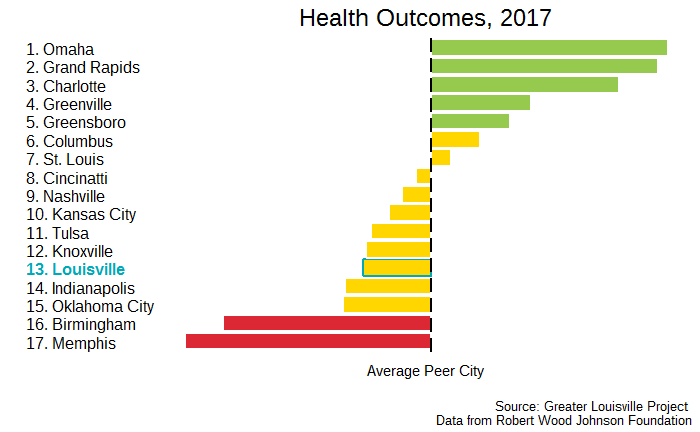

```r
rank_and_nb_group(chr_z, "outcomes", plot_title = "Health Outcomes, 2017", caption_text = "\n Source: Greater Louisville Project \n Data from Robert Wood Johnson Foundation")
```

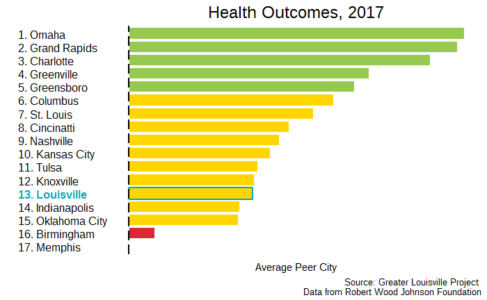

```r
rank_and_nb_group(chr_rescale, "outcomes", plot_title = "Health Outcomes, 2017", caption_text = "Source: Greater Louisville Project \n Data from Robert Wood Johnson Foundation")
```

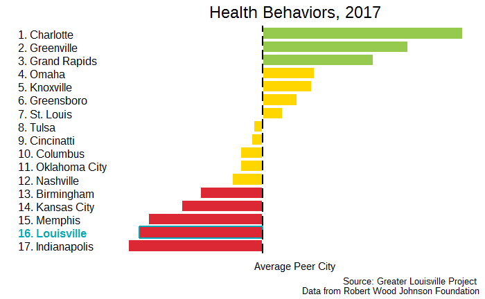

```r
rank_and_nb_group(chr_z, "health_behaviors", plot_title = "Health Behaviors, 2017", caption_text = "Source: Greater Louisville Project \n Data from Robert Wood Johnson Foundation")
```

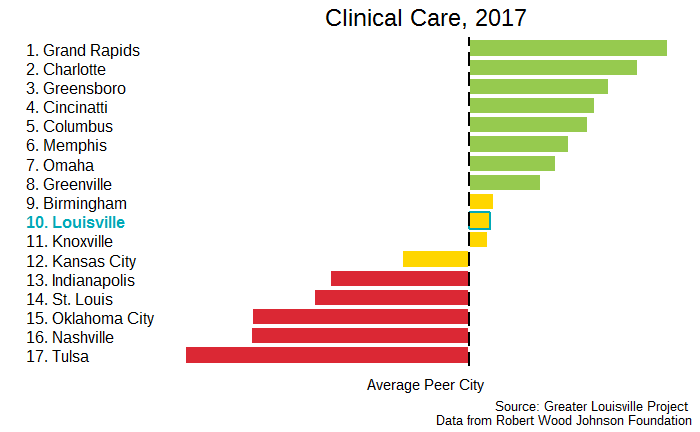

```r
rank_and_nb_group(chr_z, "clinical_care", plot_title = "Clinical Care, 2017", caption_text = "Source: Greater Louisville Project \n Data from Robert Wood Johnson Foundation")
```

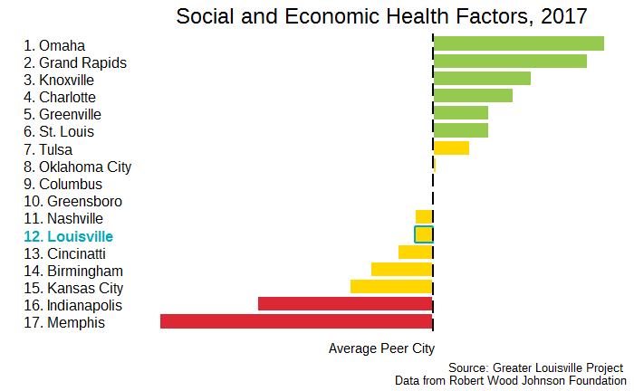

```r
rank_and_nb_group(chr_z, "social_and_economic", plot_title = "Social and Economic Health Factors, 2017", caption_text = "Source: Greater Louisville Project \n Data from Robert Wood Johnson Foundation")
```

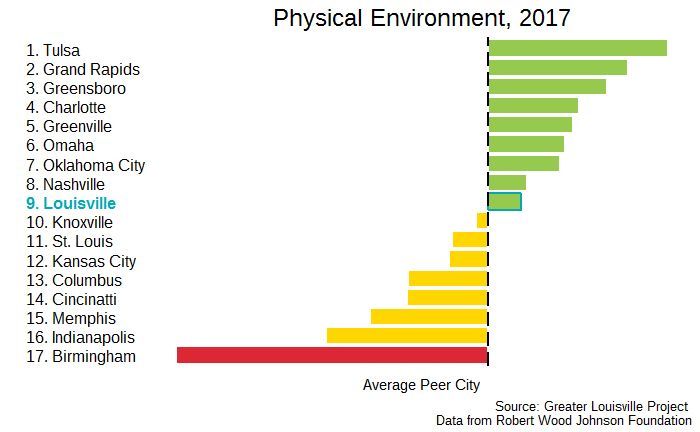

```r
rank_and_nb_group(chr_z, "physical_environment", plot_title = "Physical Environment, 2017", caption_text = "Source: Greater Louisville Project \n Data from Robert Wood Johnson Foundation")
```

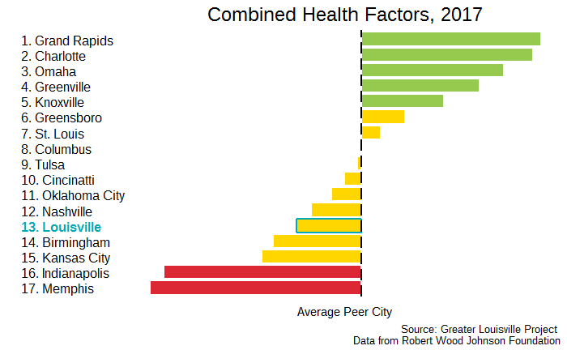

```r
rank_and_nb_group(chr_z, "factors", plot_title = "Combined Health Factors, 2017", caption_text = "Source: Greater Louisville Project \n Data from Robert Wood Johnson Foundation")
```